# Multiway data and charts

2022-07-15

In working with longitudinal Student Unit Records (SURs), we regularly encounter data structured as *multiway data*. We explore that data visually using *multiway dot plots* as described by William Cleveland (1993, pp. 302–306). Quotations, unless noted otherwise, are from this source.

Note that “multiway” in our context refers to the data structure and chart design defined by Cleveland, not to the methods of analysis described by Kroonenberg (2008).

## Definitions

**multiway data**

A data set of three variables: a category with *m* levels; a second independent category with *n* levels; and a quantitative variable (the *response*) of length *mn* such that “there is a value of the response for each combination of levels of the two categorical variables.”

**multiway chart**

A multi-panel dot plot: horizontal, quantitative scales; rows that encode one category; and panels that encode the second category. All panels have identical axes. The ordering of the rows and panels is “crucial to the perception of effects.”

**multiway superposition**

Multiway data can be extended to include a third category of *p* levels; the quantitative response has length *mnp*, one for each combination of levels of *three* categories; the rows and panels encode the first two categories as usual; *p* data markers encode the third category on each row. In general, clarity suffers for *p* > 2.

## Method

We start with a data set from the case study Results vignette, containing data from four engineering programs (Civil, Electrical, Industrial/Systems, and Mechanical Engineering) grouped by program, race/ethnicity, and sex. These data have been filtered for data sufficiency, degree seeking, program, and (for graduates) timely completion.

We prepare the data for use as input to `condition_multiway()` and use the results to construct multiway charts ordered by category median values and by category percentage values.

**Reminder.** These are practice data, not research data—suitable for learning about student-record analysis, but not for drawing inferences about program attributes or student experiences.

## Summarized data

If you are writing your own script to follow along, we start with these packages:

```r
# Packages
library("midfieldr")
suppressPackageStartupMessages(library("data.table"))
suppressPackageStartupMessages(library("ggplot2"))

# Printing options for data.table
options(
  datatable.print.nrows = 18,
  datatable.print.topn = 8,
  datatable.print.class = TRUE
)
```

**Loading.** The data file `study_results` is bundled with midfieldr.

```r
# View the case study results
DT <- copy(study_results)
DT[]
```

```
#>     program    sex            race  ever  grad stick
#>      <char> <char>          <char> <int> <int> <num>
#>  1:      CE Female           Asian    16     9  56.2
#>  2:      CE Female           Black    49    15  30.6
#>  3:      CE Female Hispanic/Latinx    10     5  50.0
#>  4:      CE Female   International     1     0   0.0
#>  5:      CE Female   Other/Unknown     6     2  33.3
#>  6:      CE Female           White   304   156  51.3
#>  7:      CE   Male           Asian    34    17  50.0
#>  8:      CE   Male           Black    90    25  27.8
#> ---
#> 48:      ME Female           White   261   109  41.8
#> 49:      ME   Male           Asian   118    58  49.2
#> 50:      ME   Male           Black   202    65  32.2
#> 51:      ME   Male Hispanic/Latinx    76    29  38.2
#> 52:      ME   Male   International    36    16  44.4
#> 53:      ME   Male Native American    14     4  28.6
#> 54:      ME   Male   Other/Unknown    43    20  46.5
#> 55:      ME   Male           White  1776   918  51.7
```

You can view the help page (and data dictionary) by running

```r
# Run in Console
? study_results
```

## Filtering before dissemination

**Filtering.** Human subject privacy is potentially at risk for small populations even with anonymized observations. Therefore, before tabulating or graphing the data for dissemination, we omit observations with fewer than 10 students ever enrolled. The magnitude of the bound (`ever >= 10`) can vary depending on one’s data.

```r
# Protecting privacy of small populations
DT <- DT[ever >= 10]
```

**Filtering.** Having reviewed these specific results in advance, we find that the small-population filter (in this case) removes Native American students from all but one of the programs—so we omit them as well.

```r
# Optional filter
DT <- DT[!race %chin% c("Native American")]
```

**Filtering.** In many studies we also omit rows in which race/ethnicity values are ambiguous.

```r
# Ambiguous race/ethnicity values
DT <- DT[!race %chin% c("International", "Other/Unknown")]
DT[]
```

```
#>     program    sex            race  ever  grad stick
#>      <char> <char>          <char> <int> <int> <num>
#>  1:      CE Female           Asian    16     9  56.2
#>  2:      CE Female           Black    49    15  30.6
#>  3:      CE Female Hispanic/Latinx    10     5  50.0
#>  4:      CE Female           White   304   156  51.3
#>  5:      CE   Male           Asian    34    17  50.0
#>  6:      CE   Male           Black    90    25  27.8
#>  7:      CE   Male Hispanic/Latinx    53    22  41.5
#>  8:      CE   Male           White  1043   558  53.5
#> ---
#> 25:      ME Female           Asian    22    13  59.1
#> 26:      ME Female           Black    75    23  30.7
#> 27:      ME Female Hispanic/Latinx    10     4  40.0
#> 28:      ME Female           White   261   109  41.8
#> 29:      ME   Male           Asian   118    58  49.2
#> 30:      ME   Male           Black   202    65  32.2
#> 31:      ME   Male Hispanic/Latinx    76    29  38.2
#> 32:      ME   Male           White  1776   918  51.7
```

## Preparing the categorical variables

Before we apply the `condition_multiway()` function, we edit the categorical variables to create the forms we want in the final charts or tables.

**Recoding.** The first multiway categorical variable is `program`. To improve the readability of the charts, we recode the program abbreviations.

```r
# Recode for panel and row labels
DT[, program := fcase(
  program %like% "CE", "Civil",
  program %like% "EE", "Electrical",
  program %like% "ME", "Mechanical",
  program %like% "ISE", "Industrial/Systems"
)]
```

**Creating a variable.** We combine `race` and `sex` into a single categorical variable (denoted `people`) as our second, independent categorical variable.

```r
# Create a new category
DT[, people := paste(race, sex)]
setcolorder(DT, c("program", "people", "race", "sex"))
DT[]
```

```
#>        program                 people            race    sex  ever  grad stick
#>         <char>                 <char>          <char> <char> <int> <int> <num>
#>  1:      Civil           Asian Female           Asian Female    16     9  56.2
#>  2:      Civil           Black Female           Black Female    49    15  30.6
#>  3:      Civil Hispanic/Latinx Female Hispanic/Latinx Female    10     5  50.0
#>  4:      Civil           White Female           White Female   304   156  51.3
#>  5:      Civil             Asian Male           Asian   Male    34    17  50.0
#>  6:      Civil             Black Male           Black   Male    90    25  27.8
#>  7:      Civil   Hispanic/Latinx Male Hispanic/Latinx   Male    53    22  41.5
#>  8:      Civil             White Male           White   Male  1043   558  53.5
#> ---
#> 25: Mechanical           Asian Female           Asian Female    22    13  59.1
#> 26: Mechanical           Black Female           Black Female    75    23  30.7
#> 27: Mechanical Hispanic/Latinx Female Hispanic/Latinx Female    10     4  40.0
#> 28: Mechanical           White Female           White Female   261   109  41.8
#> 29: Mechanical             Asian Male           Asian   Male   118    58  49.2
#> 30: Mechanical             Black Male           Black   Male   202    65  32.2
#> 31: Mechanical   Hispanic/Latinx Male Hispanic/Latinx   Male    76    29  38.2
#> 32: Mechanical             White Male           White   Male  1776   918  51.7
```

At this point, the multiway categories (`programs` and `people`) are “character” class.

## `condition_multiway()`

Converts the categorical variables to factors ordered by the quantitative variable. You can view the help page by running

```r
# Run in Console
? condition_multiway
```

**Arguments:**

**`dframe`**

Data frame with multiway data in columns. Two additional numeric columns required when using the percentage ordering method.

**`x`**

Name (in quotes) of the single multiway quantitative variable.

**`yy`**

Vector of names (in quotes) of the two multiway categorical variables.

**`order_by`**

“median” (default) or “percent”, method of ordering the levels of the categories.

**`param_col`**

Vector with the names (in quotes) of the numerator and denominator columns that produced the quantitative variable, required when using percentage ordering method.

**Columns added:**

Two columns of calculated summaries of the quantitative variable grouped by the categories. The column names and values depend on the ordering method:

- `order_by = "median"` yields medians of the quantitative variable grouped by the categorical variables.
- `order_by = "percent"` yields percentages based on the same ratio that produces the quantitative variable but grouped by the categorical variables.

## Median-ordered data

For this example, we select the count of graduates (`grad`) as our quantitative variable and use `condition_multiway()` to order the categories by median numbers of graduates.

To minimize the number of columns in the printout, we select the three multiway variables and drop other columns.

```r
# Select multiway variables when quantity is count
DT_count <- copy(DT)
DT_count <- DT_count[, .(program, people, grad)]
DT_count[]
```

```
#>        program                 people  grad
#>         <char>                 <char> <int>
#>  1:      Civil           Asian Female     9
#>  2:      Civil           Black Female    15
#>  3:      Civil Hispanic/Latinx Female     5
#>  4:      Civil           White Female   156
#>  5:      Civil             Asian Male    17
#>  6:      Civil             Black Male    25
#>  7:      Civil   Hispanic/Latinx Male    22
#>  8:      Civil             White Male   558
#> ---
#> 25: Mechanical           Asian Female    13
#> 26: Mechanical           Black Female    23
#> 27: Mechanical Hispanic/Latinx Female     4
#> 28: Mechanical           White Female   109
#> 29: Mechanical             Asian Male    58
#> 30: Mechanical             Black Male    65
#> 31: Mechanical   Hispanic/Latinx Male    29
#> 32: Mechanical             White Male   918
```

Applying `condition_multiway()`, we specify `"grad"` as the quantitative column, `"program"` and `"people"` as the two categorical columns, and `"median"` as the method of ordering levels.

```r
# Convert categories to factors ordered by median
DT_count <- condition_multiway(DT_count,
                               x = "grad",
                               yy = c("program", "people"),
                               order_by = "median")
DT_count[]
```

```
#>        program                 people  grad program_median people_median
#>         <fctr>                 <fctr> <int>          <num>         <num>
#>  1:      Civil           Asian Female     9           19.5          13.5
#>  2:      Civil           Black Female    15           19.5          33.0
#>  3:      Civil Hispanic/Latinx Female     5           19.5           5.5
#>  4:      Civil           White Female   156           19.5         117.5
#>  5:      Civil             Asian Male    17           19.5          46.0
#>  6:      Civil             Black Male    25           19.5          55.5
#>  7:      Civil   Hispanic/Latinx Male    22           19.5          22.0
#>  8:      Civil             White Male   558           19.5         533.5
#> ---
#> 25: Mechanical           Asian Female    13           43.5          13.5
#> 26: Mechanical           Black Female    23           43.5          33.0
#> 27: Mechanical Hispanic/Latinx Female     4           43.5           5.5
#> 28: Mechanical           White Female   109           43.5         117.5
#> 29: Mechanical             Asian Male    58           43.5          46.0
#> 30: Mechanical             Black Male    65           43.5          55.5
#> 31: Mechanical   Hispanic/Latinx Male    29           43.5          22.0
#> 32: Mechanical             White Male   918           43.5         533.5
```

The function adds two columns (`program_median` and `people_median`) to display the computed median values used to order the factors. In the median method, the new column names are a combination of the category variable names (from `yy`) plus `median`.

For example, the results show that the median number of Civil Engineering graduates is 19.5 and that the median number of Asian Female graduates is 13.5. We confirm these results by computing the median values independently.

The following values agree with those in the `program_median` variable above,

```r
# Verify condition_multiway() output
temp <- DT_count[, lapply(.SD, median), .SDcols = c("grad"), by = c("program")]
temp[]
```

```
#>               program  grad
#>                <fctr> <num>
#> 1:              Civil  19.5
#> 2:         Electrical  56.5
#> 3: Industrial/Systems  38.5
#> 4:         Mechanical  43.5
```

And the next result agrees with the values in `people_median`.

```r
# Verify condition_multiway() output
temp <- DT_count[, lapply(.SD, median), .SDcols = c("grad"), by = c("people")]
temp[]
```

```
#>                    people  grad
#>                    <fctr> <num>
#> 1:           Asian Female  13.5
#> 2:           Black Female  33.0
#> 3: Hispanic/Latinx Female   5.5
#> 4:           White Female 117.5
#> 5:             Asian Male  46.0
#> 6:             Black Male  55.5
#> 7:   Hispanic/Latinx Male  22.0
#> 8:             White Male 533.5
```

In the output, you can see that both categories are “factor” class: `program` is a factor with 4 levels; `people` is a factor with 8 levels; and neither is ordered alphabetically—ordering is by increasing median value as expected.

```r
# Verify first category is a factor
levels(DT_count$program)
```

```
#> [1] "Civil"              "Industrial/Systems" "Mechanical"
#> [4] "Electrical"
```

```r
# Verify second category is a factor
levels(DT_count$people)
```

```
#> [1] "Hispanic/Latinx Female" "Asian Female"           "Hispanic/Latinx Male"
#> [4] "Black Female"           "Asian Male"             "Black Male"
#> [7] "White Female"           "White Male"
```

Because the `order_by` argument has a default value of “median”, the following two code chunks produce identical results.

```r
# Using explicit order_by median
p <- condition_multiway(DT_count,
                   x = "grad",
                   yy = c("program", "people"),
                   order_by = "median")

# Using implicit order_by median
q <- condition_multiway(DT_count,
                   x = "grad",
                   yy = c("program", "people"))

# Verify results identical
all.equal(p, q)
```

```
#> [1] TRUE
```

## Median-ordered charts

We use conventional ggplot2 functions to create the multiway graphs.

We create a set of axis labels and scale specifications for a series of median-ordered charts. We use a logarithmic scale in this case because the numbers span three orders of magnitude.

```r
# Common x-scale and axis labels for median-ordered charts
common_scale_x_log10 <- scale_x_log10(
    limits = c(3, 1000),
    breaks = c(3, 10, 30, 100, 300, 1000),
    minor_breaks = c(seq(3, 10, 1), seq(20, 100, 10), seq(200, 1000, 100))
)
common_labs <- labs(
    x = "Number of graduates (log base 10 scale)",
    y = "",
    title = "Engineering graduates"
)

# Draw vertical lines in panels
common_geom_vline <- function(x){
    geom_vline(aes(xintercept = x),
               linetype = 2,
               color = "gray70")
}
```

The first of two multiway charts encodes *programs by rows* and *people by panels*. The `as.table = FALSE` argument places rows and panels in “graphical order”, that is, increasing from left to right and from bottom to top. The panel median value is drawn as a vertical reference line in each panel.

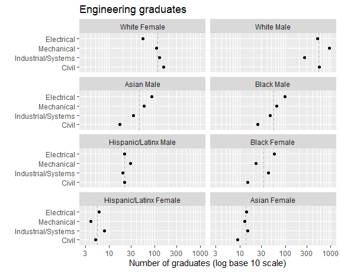

```r
# Two columns of panels
ggplot(DT_count, aes(x = grad, y = program)) +
    facet_wrap(vars(people), ncol = 2, as.table = FALSE) +
    common_geom_vline(DT_count$people_median) +
    common_scale_x_log10 +
    common_labs +
    geom_point()
```

The programs are assigned to rows such that the program medians increase from bottom to top. Civil Engineering has the smallest median; Electrical Engineering the largest.

We drew the chart above in two columns to illustrate the graph order of panels. Hispanic/LatinX Female students have the smallest median number of graduates, followed by Asian Female students, Hispanic/LatinX Male students, Black Female students, etc.

When space permits, however, laying out the panels in a single column can be useful for seeing effects. Here, we redraw the panels in one column.

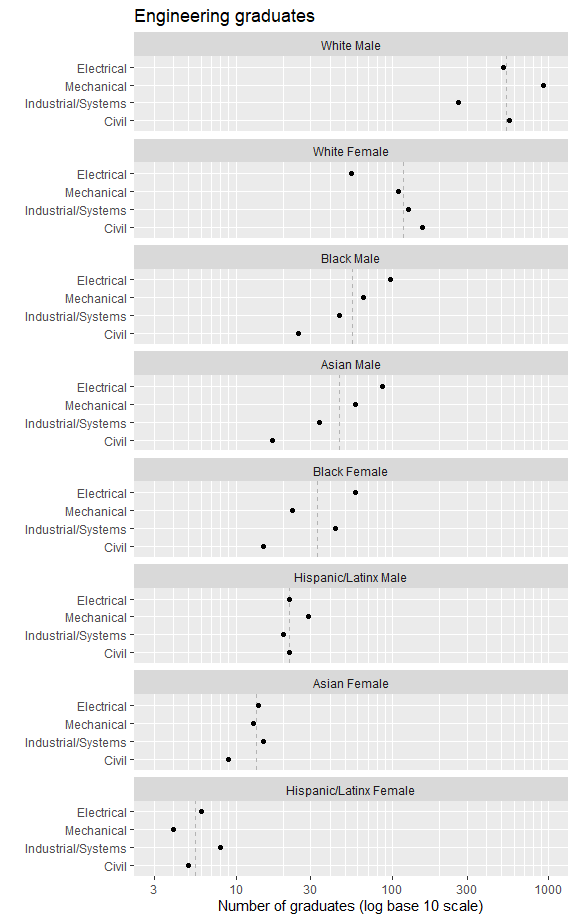

```r
# Programs encoded by rows
ggplot(DT_count, aes(x = grad, y = program)) +
    facet_wrap(vars(people), ncol = 1, as.table = FALSE) +
    common_geom_vline(DT_count$people_median) +
    common_scale_x_log10 +
    common_labs +
    geom_point()
```

Reading a multiway graph

- We can more effectively compare values within a panel than between panels.
- Because rows are ordered, one expects a generally increasing trend within a panel. A response greater or smaller than expected creates a visual asymmetry. The interesting stories are often in these visual anomalies.

For example, the top panel clearly shows the variability of the White Male data across four programs; the White Female panel shows a clear counter-trend—their numbers decrease as the program medians increase.

However, this chart does not permit us to effectively compare the eight values for a given program. For that we create a second multiway in which we switch the aesthetic roles of the categories—in this example by encoding *people by rows* and *programs by panels*.

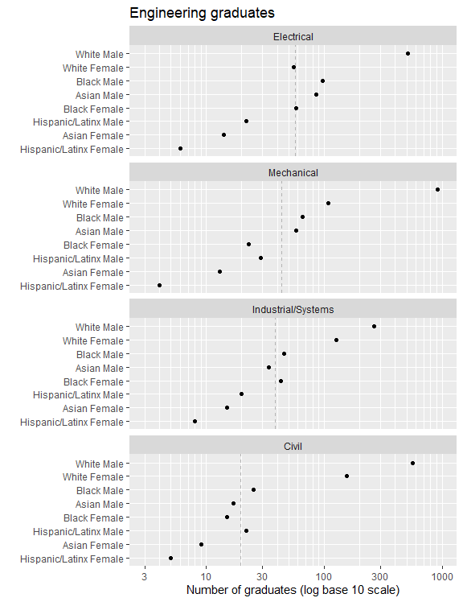

```r
# People encoded by rows
ggplot(DT_count, aes(x = grad, y = people)) +
    facet_wrap(vars(program), ncol = 1, as.table = FALSE) +
    common_geom_vline(DT_count$program_median) +
    common_scale_x_log10 +
    common_labs +
    geom_point()
```

In this chart, the visual asymmetries that stand out are

- Electrical Engineering, White Female, low given their overall rank
- Mechanical Engineering, Black Female, low given their overall rank
- Industrial/Systems Engineering, Black Female, high given their overall rank
- Civil Engineering, Hispanic/LatinX Male, high given their overall rank

## Avoid alphabetical order

In the next figure, the same data are plotted in alphabetical order.

The effects seen in the previous chart are not revealed.

- That White Female graduates are fewer than expected in Electrical Engineering is not apparent
- That Hispanic/LatinX Male graduates are higher than expected in Civil Engineering is not apparent
- etc.

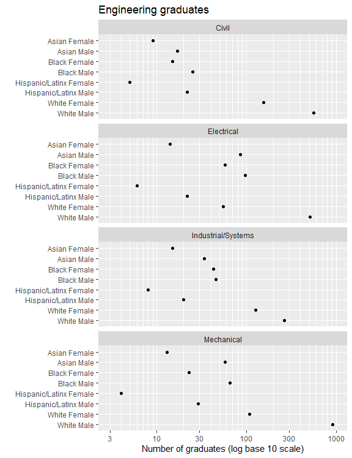

```r
# Create alphabetical odering
DT_alpha <- copy(DT)
DT_alpha[, people := factor(people, levels = sort(unique(people), decreasing = TRUE))]

# People encoded by rows, alphabetically
ggplot(DT_alpha, aes(x = grad, y = people)) +
    facet_wrap(vars(program), ncol = 1, as.table = TRUE) +
    common_scale_x_log10 +
    common_labs +
    geom_point()
```

An ordering scheme based on the values of the quantitative variable is necessary if a multiway chart is to reveal how the response is affected by the categories.

## Multiway superposition

To illustrate superposing data, we return to the data set with separate columns for race/ethnicity and sex. Let’s use `grad` as our quantitative variable and omit unnecessary variables.

```r
# Select multiway variables with a superposed category
DT_count <- copy(DT)
DT_count <- DT_count[, .(program, race, sex, grad)]
DT_count[]
```

```
#>        program            race    sex  grad
#>         <char>          <char> <char> <int>
#>  1:      Civil           Asian Female     9
#>  2:      Civil           Black Female    15
#>  3:      Civil Hispanic/Latinx Female     5
#>  4:      Civil           White Female   156
#>  5:      Civil           Asian   Male    17
#>  6:      Civil           Black   Male    25
#>  7:      Civil Hispanic/Latinx   Male    22
#>  8:      Civil           White   Male   558
#> ---
#> 25: Mechanical           Asian Female    13
#> 26: Mechanical           Black Female    23
#> 27: Mechanical Hispanic/Latinx Female     4
#> 28: Mechanical           White Female   109
#> 29: Mechanical           Asian   Male    58
#> 30: Mechanical           Black   Male    65
#> 31: Mechanical Hispanic/Latinx   Male    29
#> 32: Mechanical           White   Male   918
```

The superposed category is `sex`. The multiway data to be conditioned are `grad`, the quantitative variable, and `program` and `race`, the two categorical variables.

```r
# Convert categories to factors ordered by median
DT_count <- condition_multiway(DT_count,
                               x = "grad",
                               yy = c("program", "race"))
DT_count[]
```

```
#>        program            race  grad    sex program_median race_median
#>         <fctr>          <fctr> <int> <char>          <num>       <num>
#>  1:      Civil           Asian     9 Female           19.5        16.0
#>  2:      Civil           Black    15 Female           19.5        44.5
#>  3:      Civil Hispanic/Latinx     5 Female           19.5        14.0
#>  4:      Civil           White   156 Female           19.5       209.5
#>  5:      Civil           Asian    17   Male           19.5        16.0
#>  6:      Civil           Black    25   Male           19.5        44.5
#>  7:      Civil Hispanic/Latinx    22   Male           19.5        14.0
#>  8:      Civil           White   558   Male           19.5       209.5
#> ---
#> 25: Mechanical           Asian    13 Female           43.5        16.0
#> 26: Mechanical           Black    23 Female           43.5        44.5
#> 27: Mechanical Hispanic/Latinx     4 Female           43.5        14.0
#> 28: Mechanical           White   109 Female           43.5       209.5
#> 29: Mechanical           Asian    58   Male           43.5        16.0
#> 30: Mechanical           Black    65   Male           43.5        44.5
#> 31: Mechanical Hispanic/Latinx    29   Male           43.5        14.0
#> 32: Mechanical           White   918   Male           43.5       209.5
```

In this example, `program` and `race` are factors, ordered by median number of graduates while `sex` remains an unordered character variable.

Using conventional ggplot syntax, the aesthetics include `x` and `y` as before. We superpose data markers for sex in rows by assigning `color = sex` inside the `aes()` function.

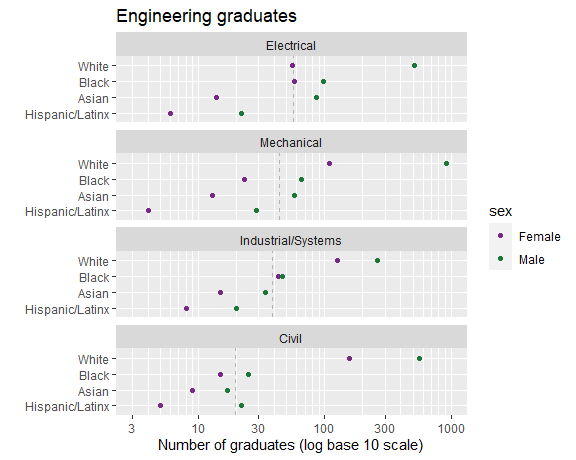

```r
# Race/ethnicity encoded by rows, sex superposed
ggplot(DT_count, aes(x = grad, y = race, color = sex)) +
    facet_wrap(vars(program), ncol = 1, as.table = FALSE) +
    common_geom_vline(DT_count$program_median) +
    common_scale_x_log10 +
    common_labs +
    geom_point() +
    scale_color_manual(values = c("#762A83", "#1B7837"))
```

By superposing data by sex, we facilitate a direct comparison of Male and Female students within a program and by race.

Swapping rows and panels yields the next chart, in which we can directly compare Male and Female students within their race/ethnicity category across programs. Because men tend to outnumber women in engineering programs, this chart clearly shows clusters by sex.

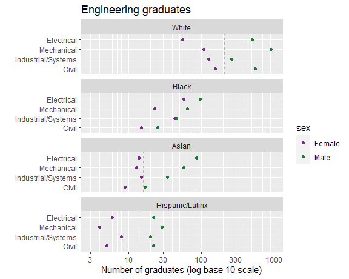

```r
# Program encoded by rows, sex superposed
ggplot(DT_count, aes(x = grad, y = program, color = sex)) +
    facet_wrap(vars(race), ncol = 1, as.table = FALSE) +
    common_geom_vline(DT_count$race_median) +
    common_scale_x_log10 +
    common_labs +
    geom_point() +
    scale_color_manual(values = c("#762A83", "#1B7837"))
```

## Percentage-ordered data

For persistence metrics such as stickiness or graduation rate, the quantitative variable is a ratio or percentage. Here, we return to the original case study results and select stickiness (`stick`) as the quantitative variable.

```r
# Select multiway variables when quantity is a percentage
options(datatable.print.topn = 3)
DT_ratio <- copy(DT)
DT_ratio[, c("race", "sex") := NULL]
DT_ratio[]
```

```
#>        program                 people  ever  grad stick
#>         <char>                 <char> <int> <int> <num>
#>  1:      Civil           Asian Female    16     9  56.2
#>  2:      Civil           Black Female    49    15  30.6
#>  3:      Civil Hispanic/Latinx Female    10     5  50.0
#> ---
#> 30: Mechanical             Black Male   202    65  32.2
#> 31: Mechanical   Hispanic/Latinx Male    76    29  38.2
#> 32: Mechanical             White Male  1776   918  51.7
```

Because stickiness is a ratio, we set `order_by` to “percent” and assign `grad` and `ever` to the `param_col` argument. `condition_multiway()` then sums the `ever` and `grad` counts by category and produces grouped percentages to order the category levels.

```r
# Convert categories to factors ordered by group percentages
DT_ratio <- condition_multiway(DT_ratio,
                               x = "stick",
                               yy = c("program", "people"),
                               order_by = "percent",
                               param_col = c("grad", "ever"))
DT_ratio[]
```

```
#>        program                 people  grad  ever stick program_stick
#>         <fctr>                 <fctr> <num> <num> <num>         <num>
#>  1:      Civil           Asian Female     9    16  56.2          50.5
#>  2:      Civil           Black Female    15    49  30.6          50.5
#>  3:      Civil Hispanic/Latinx Female     5    10  50.0          50.5
#> ---
#> 30: Mechanical             Black Male    65   202  32.2          48.0
#> 31: Mechanical   Hispanic/Latinx Male    29    76  38.2          48.0
#> 32: Mechanical             White Male   918  1776  51.7          48.0
#>     people_stick
#>            <num>
#>  1:         44.0
#>  2:         38.4
#>  3:         48.9
#> ---
#> 30:         34.2
#> 31:         41.5
#> 32:         49.5
```

The function again converts the categories to factors and adds two columns (`program_stick` and `people_stick`) to display the computed percentages used to order the factors. In the percentage method, the new column names are a combination of the category variable names (from `yy`) plus the quantitative column name (from `x`).

For example, the results show that the stickiness of Civil Engineering (`program_stick`) is 50.5%, and of Asian Females, 44% (`people_stick`). We confirm these results by computing the group stickiness values independently.

The following values agree with those in the `program_stick` variable above,

```r
# Verify condition_multiway() output
temp <- DT[, lapply(.SD, sum), .SDcols = c("ever", "grad"), by = c("program")]
temp[, stick := round(100 *grad / ever, 1)]
temp[]
```

```
#>               program  ever  grad stick
#>                <char> <int> <int> <num>
#> 1:              Civil  1599   807  50.5
#> 2:         Electrical  2134   847  39.7
#> 3: Industrial/Systems  1076   555  51.6
#> 4:         Mechanical  2540  1219  48.0
```

And the next result agrees with the values in `people_stick`.

```r
# Verify condition_multiway() output
temp <- DT[, lapply(.SD, sum), .SDcols = c("ever", "grad"), by = c("people")]
temp[, stick := round(100 *grad / ever, 1)]
temp[]
```

```
#>                    people  ever  grad stick
#>                    <char> <int> <int> <num>
#> 1:           Asian Female   116    51  44.0
#> 2:           Black Female   362   139  38.4
#> 3: Hispanic/Latinx Female    47    23  48.9
#> 4:           White Female   972   446  45.9
#> 5:             Asian Male   406   195  48.0
#> 6:             Black Male   682   233  34.2
#> 7:   Hispanic/Latinx Male   224    93  41.5
#> 8:             White Male  4540  2248  49.5
```

## Percentage-ordered charts

Here the quantitative variable is group stickiness. The first chart encodes *programs by rows* and *people by panels*.

The order of rows and panels has changed from the earlier charts.

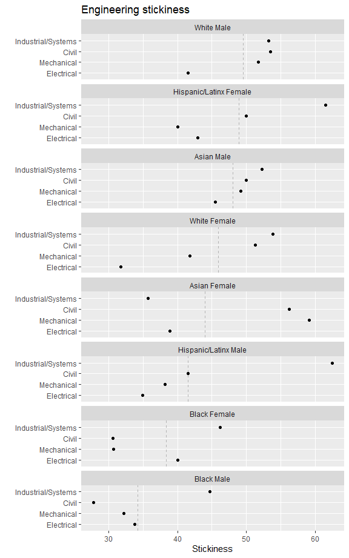

```r
# Programs encoded by rows
ggplot(DT_ratio, aes(x = stick, y = program)) +
    facet_wrap(vars(people), ncol = 1, as.table = FALSE) +
    common_geom_vline(DT_ratio$people_stick) +
    labs(x = "Stickiness", y = "", title = "Engineering stickiness") +
    geom_point()
```

The visual asymmetries in this chart that stand out are

- Electrical Engineering, White Female, low given their overall rank
- Hispanic/LatinX Female, Mechanical Engineering, low given their overall rank
- Asian Female, Industrial/Systems Engineering, low given their overall rank
- Black Female and Male in Civil and Mechanical Engineering, low given their overall rank

Again, we cannot compare the eight values for a given program as effectively. This is done far better in the second chart that encodes *people by rows* and *programs by panels*.

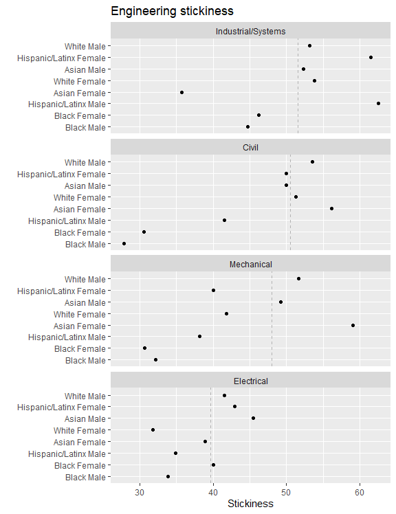

```r
# People encoded by rows
ggplot(DT_ratio, aes(x = stick, y = people)) +
    facet_wrap(vars(program), ncol = 1, as.table = FALSE) +
    common_geom_vline(DT_ratio$program_stick) +
    labs(x = "Stickiness", y = "", title = "Engineering stickiness") +
    geom_point()
```

This chart shows a lot of variability. The visual asymmetries that stand out are

- Hispanic/LatinX Female and Male, Industrial/Systems Engineering, high given their overall rank
- Asian Female, Civil and Mechanical Engineering, high given their overall rank
- White Female, Electrical Engineering, low given their overall rank
- Asian Male, Electrical Engineering, high given their overall rank

## Tabulating counts

Readers and reviewers of charts often want to see the exact numbers represented by data markers. To serve that need, we tabulate multiway data after transforming it from block-record form (convenient for use with ggplot2) to row-record form, that is, from “long” to “wide” form.

To illustrate, let’s tabulate the number of graduates by people and program. Start by selecting the desired variables only.

```r
# Select the desired variables
tbl <- copy(DT)
tbl <- tbl[, .(program, people, grad)]
tbl[]
```

```
#>        program                 people  grad
#>         <char>                 <char> <int>
#>  1:      Civil           Asian Female     9
#>  2:      Civil           Black Female    15
#>  3:      Civil Hispanic/Latinx Female     5
#> ---
#> 30: Mechanical             Black Male    65
#> 31: Mechanical   Hispanic/Latinx Male    29
#> 32: Mechanical             White Male   918
```

Use `dcast()` to transform the block records to row records.

```r
# Transform shape to row-record form
tbl <- dcast(tbl, people ~ program, value.var = "grad")
tbl[]
```

```
#>                    people Civil Electrical Industrial/Systems Mechanical
#>                    <char> <int>      <int>              <int>      <int>
#> 1:           Asian Female     9         14                 15         13
#> 2:             Asian Male    17         86                 34         58
#> 3:           Black Female    15         58                 43         23
#> 4:             Black Male    25         97                 46         65
#> 5: Hispanic/Latinx Female     5          6                  8          4
#> 6:   Hispanic/Latinx Male    22         22                 20         29
#> 7:           White Female   156         55                126        109
#> 8:             White Male   558        509                263        918
```

Edit one column name and print the table.

```r
# Edit column header
setnames(tbl, old = "people", new = "Group", skip_absent = TRUE)
```

Table 1: Number of engineering graduates

| Group | Civil | Electrical | Industrial/Systems | Mechanical |
| --- | --- | --- | --- | --- |
| Asian Female | 9 | 14 | 15 | 13 |
| Asian Male | 17 | 86 | 34 | 58 |
| Black Female | 15 | 58 | 43 | 23 |
| Black Male | 25 | 97 | 46 | 65 |
| Hispanic/Latinx Female | 5 | 6 | 8 | 4 |
| Hispanic/Latinx Male | 22 | 22 | 20 | 29 |
| White Female | 156 | 55 | 126 | 109 |
| White Male | 558 | 509 | 263 | 918 |

Multiway data structure lends itself to tables of this type. The levels of one category are in the first column; the levels of the second category are in the table header; and the quantitative variable fills the cells—a response value for each combination of levels of the two categories.

## Tabulating percentages

When tabulating percentages, readers and reviewers are likely to want the percentage values as well as the underlying ratios of integers. In this example, we suggest one way these values can be presented in a single table.

```r
# Select the desired variables
tbl <- copy(DT)
tbl <- tbl[, .(program, people, grad, ever, stick)]
tbl[]
```

```
#>        program                 people  grad  ever stick
#>         <char>                 <char> <int> <int> <num>
#>  1:      Civil           Asian Female     9    16  56.2
#>  2:      Civil           Black Female    15    49  30.6
#>  3:      Civil Hispanic/Latinx Female     5    10  50.0
#> ---
#> 30: Mechanical             Black Male    65   202  32.2
#> 31: Mechanical   Hispanic/Latinx Male    29    76  38.2
#> 32: Mechanical             White Male   918  1776  51.7
```

In this step, we concatenate a character string with the ratio of integers in parentheses followed by the resulting percentage value. e.g., `(9/16) 56.2`.

```r
# Construct new cell values
tbl[, results := paste0("(", grad, "/", ever, ") ", format(stick, nsmall = 1))]
tbl[]
```

```
#>        program                 people  grad  ever stick         results
#>         <char>                 <char> <int> <int> <num>          <char>
#>  1:      Civil           Asian Female     9    16  56.2     (9/16) 56.2
#>  2:      Civil           Black Female    15    49  30.6    (15/49) 30.6
#>  3:      Civil Hispanic/Latinx Female     5    10  50.0     (5/10) 50.0
#> ---
#> 30: Mechanical             Black Male    65   202  32.2   (65/202) 32.2
#> 31: Mechanical   Hispanic/Latinx Male    29    76  38.2    (29/76) 38.2
#> 32: Mechanical             White Male   918  1776  51.7 (918/1776) 51.7
```

Now we can perform the transformation from block records to row records as we did above.

```r
# Transform shape to row-record form
tbl <- dcast(tbl, people ~ program, value.var = "results")
tbl[]
```

```
#>                    people           Civil      Electrical Industrial/Systems
#>                    <char>          <char>          <char>             <char>
#> 1:           Asian Female     (9/16) 56.2    (14/36) 38.9       (15/42) 35.7
#> 2:             Asian Male    (17/34) 50.0   (86/189) 45.5       (34/65) 52.3
#> 3:           Black Female    (15/49) 30.6   (58/145) 40.0       (43/93) 46.2
#> 4:             Black Male    (25/90) 27.8   (97/287) 33.8      (46/103) 44.7
#> 5: Hispanic/Latinx Female     (5/10) 50.0     (6/14) 42.9        (8/13) 61.5
#> 6:   Hispanic/Latinx Male    (22/53) 41.5    (22/63) 34.9       (20/32) 62.5
#> 7:           White Female  (156/304) 51.3   (55/173) 31.8     (126/234) 53.8
#> 8:             White Male (558/1043) 53.5 (509/1227) 41.5     (263/494) 53.2
#>         Mechanical
#>             <char>
#> 1:    (13/22) 59.1
#> 2:   (58/118) 49.2
#> 3:    (23/75) 30.7
#> 4:   (65/202) 32.2
#> 5:     (4/10) 40.0
#> 6:    (29/76) 38.2
#> 7:  (109/261) 41.8
#> 8: (918/1776) 51.7
```

Edit one column name and print the table.

```r
# Edit column header
setnames(tbl, old = "people", new = "Group", skip_absent = TRUE)
```

Table 2: Percent stickiness of four engineering programs

| Group | Civil | Electrical | Industrial/Systems | Mechanical |
| --- | --- | --- | --- | --- |
| Asian Female | (9/16) 56.2 | (14/36) 38.9 | (15/42) 35.7 | (13/22) 59.1 |
| Asian Male | (17/34) 50.0 | (86/189) 45.5 | (34/65) 52.3 | (58/118) 49.2 |
| Black Female | (15/49) 30.6 | (58/145) 40.0 | (43/93) 46.2 | (23/75) 30.7 |
| Black Male | (25/90) 27.8 | (97/287) 33.8 | (46/103) 44.7 | (65/202) 32.2 |
| Hispanic/Latinx Female | (5/10) 50.0 | (6/14) 42.9 | (8/13) 61.5 | (4/10) 40.0 |
| Hispanic/Latinx Male | (22/53) 41.5 | (22/63) 34.9 | (20/32) 62.5 | (29/76) 38.2 |
| White Female | (156/304) 51.3 | (55/173) 31.8 | (126/234) 53.8 | (109/261) 41.8 |
| White Male | (558/1043) 53.5 | (509/1227) 41.5 | (263/494) 53.2 | (918/1776) 51.7 |

Note:  
Integers in parentheses give the ratio of students graduating to those ever enrolled that produces the percentage shown.

## Closing

We used longitudinal SURs to illustrate the structure of multiway data and create multiway charts and tables of several types. We demonstrated filtering data before dissemination to preserve anonymity.

We used two methods of ordering the rows and panels of multiway charts: by grouped medians when data are summary counts and by grouped percentages when data are ratios or percentages.

We illustrated that visual perception of effects is more practicable within a panel than between panels. Our advice (and Cleveland’s) is to encode the levels of each category by rows in at least one chart. Thus the minimum number of exploratory charts is the number of independent categorical variables.

## References

Cleveland, W. S. (1993). *Visualizing Data*. Hobart Press.

Dowle, M., & Srinivasan, A. (2021). *data.table: Extension of data.frame*. R package version 1.14.2. https://CRAN.R-project.org/package=data.table

Kroonenberg, P. M. (2008). *Applied Multiway Data Analysis*. Wiley.

Wickham, H. (2016). *ggplot2: Elegant Graphics for Data Analysis*. ISBN 978-3-319-24277-4; Springer-Verlag New York. https://ggplot2.tidyverse.org

## Appendix

### Complete script

The vignette code chunks are collected below in a single, condensed script.

```r
# Packages
library("midfieldr")
suppressPackageStartupMessages(library("data.table"))
suppressPackageStartupMessages(library("ggplot2"))

# Printing options for data.table
options(
  datatable.print.nrows = 18,
  datatable.print.topn = 8,
  datatable.print.class = TRUE
)

# Summarized data
DT <- copy(study_results)

# Filtering before dissemination
DT <- DT[ever >= 10]
DT <- DT[!race %chin% c("Native American")]
DT <- DT[!race %chin% c("International", "Other/Unknown")]

# Preparing the categorical variables
DT[, program := fcase(
  program %like% "CE", "Civil",
  program %like% "EE", "Electrical",
  program %like% "ME", "Mechanical",
  program %like% "ISE", "Industrial/Systems"
)]
DT[, people := paste(race, sex)]
setcolorder(DT, c("program", "people", "race", "sex"))

# Median-ordered data
DT_count <- copy(DT)
DT_count <- DT_count[, .(program, people, grad)]
DT_count <- condition_multiway(DT_count,
                               x = "grad",
                               yy = c("program", "people"),
                               order_by = "median")

# Median-ordered charts
common_scale_x_log10 <- scale_x_log10(
    limits = c(3, 1000),
    breaks = c(3, 10, 30, 100, 300, 1000),
    minor_breaks = c(seq(3, 10, 1), seq(20, 100, 10), seq(200, 1000, 100))
)
common_labs <- labs(
    x = "Number of graduates (log base 10 scale)",
    y = "",
    title = "Engineering graduates"
)
common_geom_vline <- function(x){
    geom_vline(aes(xintercept = x),
               linetype = 2,
               color = "gray70")
}

# Two-column layout
ggplot(DT_count, aes(x = grad, y = program)) +
    facet_wrap(vars(people), ncol = 2, as.table = FALSE) +
    common_geom_vline(DT_count$people_median) +
    common_scale_x_log10 +
    common_labs +
    geom_point()

# Programs encoded by rows
ggplot(DT_count, aes(x = grad, y = program)) +
    facet_wrap(vars(people), ncol = 1, as.table = FALSE) +
    common_geom_vline(DT_count$people_median) +
    common_scale_x_log10 +
    common_labs +
    geom_point()

# People encoded by rows
ggplot(DT_count, aes(x = grad, y = people)) +
    facet_wrap(vars(program), ncol = 1, as.table = FALSE) +
    common_geom_vline(DT_count$program_median) +
    common_scale_x_log10 +
    common_labs +
    geom_point()

# Avoid alphabetical order
DT_alpha <- copy(DT)
DT_alpha[, people := factor(people, levels = sort(unique(people), decreasing = TRUE))]
ggplot(DT_alpha, aes(x = grad, y = people)) +
    facet_wrap(vars(program), ncol = 1, as.table = TRUE) +
    common_scale_x_log10 +
    common_labs +
    geom_point()

# Multiway superposition
DT_count <- copy(DT)
DT_count <- DT_count[, .(program, race, sex, grad)]
DT_count <- condition_multiway(DT_count,
                               x = "grad",
                               yy = c("program", "race"))

# Race/ethnicity encoded by rows
ggplot(DT_count, aes(x = grad, y = race, color = sex)) +
    facet_wrap(vars(program), ncol = 1, as.table = FALSE) +
    common_geom_vline(DT_count$program_median) +
    common_scale_x_log10 +
    common_labs +
    geom_point() +
    scale_color_manual(values = c("#762A83", "#1B7837"))

# Program encoded by rows
ggplot(DT_count, aes(x = grad, y = program, color = sex)) +
    facet_wrap(vars(race), ncol = 1, as.table = FALSE) +
    common_geom_vline(DT_count$race_median) +
    common_scale_x_log10 +
    common_labs +
    geom_point() +
    scale_color_manual(values = c("#762A83", "#1B7837"))

# Percentage-ordered data
DT_ratio <- copy(DT)
DT_ratio[, c("race", "sex") := NULL]
DT_ratio <- condition_multiway(DT_ratio,
                               x = "stick",
                               yy = c("program", "people"),
                               order_by = "percent",
                               param_col = c("grad", "ever"))

# Percentage-ordered charts
# Programs encoded by rows
ggplot(DT_ratio, aes(x = stick, y = program)) +
    facet_wrap(vars(people), ncol = 1, as.table = FALSE) +
    common_geom_vline(DT_ratio$people_stick) +
    labs(x = "Stickiness", y = "", title = "Engineering stickiness") +
    geom_point()

# People encoded by rows
ggplot(DT_ratio, aes(x = stick, y = people)) +
    facet_wrap(vars(program), ncol = 1, as.table = FALSE) +
    common_geom_vline(DT_ratio$program_stick) +
    labs(x = "Stickiness", y = "", title = "Engineering stickiness") +
    geom_point()

# Tabulating counts
tbl <- copy(DT)
tbl <- tbl[, .(program, people, grad)]
tbl <- dcast(tbl, people ~ program, value.var = "grad")
setnames(tbl, old = "people", new = "Group", skip_absent = TRUE)

# Tabulating percentages
tbl <- copy(DT)
tbl <- tbl[, .(program, people, grad, ever, stick)]
tbl[, results := paste0("(", grad, "/", ever, ") ", format(stick, nsmall = 1))]
tbl <- dcast(tbl, people ~ program, value.var = "results")
setnames(tbl, old = "people", new = "Group", skip_absent = TRUE)
```